# Bagging

Nik Bear Brown

In this lesson we’ll learn the how to implement Bagging in R.

# Additional packages needed

To run the code you may need additional packages.

- If necessary install the followings packages.

`install.packages('randomForest');`  
`install.packages('caret');`  
`install.packages('rpart');`  
`install.packages('adabag');`  
`install.packages('ipred');`

```r
library(randomForest)
library(caret)
library(rpart)
library(adabag)
library(ipred)
```

# Data

We will be using the [UCI Machine Learning Repository: Adult Data](https://archive.ics.uci.edu/ml/datasets/Adult) to predict whether income exceeds $50K/yr based on census data. Also known as “Census Income” dataset.

```r
data_url <- 'http://nikbearbrown.com/YouTube/MachineLearning/M09/adult.data.txt'
# Adult data set from UCI
adult<- read.csv(url(data_url), header=FALSE)
head(adult)
```

```
##   V1                V2     V3         V4 V5                  V6
## 1 39         State-gov  77516  Bachelors 13       Never-married
## 2 50  Self-emp-not-inc  83311  Bachelors 13  Married-civ-spouse
## 3 38           Private 215646    HS-grad  9            Divorced
## 4 53           Private 234721       11th  7  Married-civ-spouse
## 5 28           Private 338409  Bachelors 13  Married-civ-spouse
## 6 37           Private 284582    Masters 14  Married-civ-spouse
##                   V7             V8     V9     V10  V11 V12 V13
## 1       Adm-clerical  Not-in-family  White    Male 2174   0  40
## 2    Exec-managerial        Husband  White    Male    0   0  13
## 3  Handlers-cleaners  Not-in-family  White    Male    0   0  40
## 4  Handlers-cleaners        Husband  Black    Male    0   0  40
## 5     Prof-specialty           Wife  Black  Female    0   0  40
## 6    Exec-managerial           Wife  White  Female    0   0  40
##              V14    V15
## 1  United-States  <=50K
## 2  United-States  <=50K
## 3  United-States  <=50K
## 4  United-States  <=50K
## 5           Cuba  <=50K
## 6  United-States  <=50K
```

```r
names(adult)
```

```
##  [1] "V1"  "V2"  "V3"  "V4"  "V5"  "V6"  "V7"  "V8"  "V9"  "V10" "V11"
## [12] "V12" "V13" "V14" "V15"
```

```r
adult.len <- sample(1:nrow(adult), 3*nrow(adult)/4)
head(adult.len)
```

```
## [1] 31373 29363 29039  4316  9796 21653
```

```r
train <- adult[adult.len,]
test <- adult[-adult.len,]
head(train)
```

```
##       V1                V2     V3            V4 V5                  V6
## 31373 67                 ?  34122       5th-6th  3  Married-civ-spouse
## 29363 58           Private 205235       HS-grad  9  Married-civ-spouse
## 29039 28         Local-gov 154863           9th  5  Married-civ-spouse
## 4316  56                 ? 275943  Some-college 10  Married-civ-spouse
## 9796  32         Local-gov 157887       HS-grad  9  Married-civ-spouse
## 21653 31  Self-emp-not-inc 252752       HS-grad  9  Married-civ-spouse
##                      V7       V8     V9     V10 V11  V12 V13
## 31373                 ?  Husband  White    Male   0    0  40
## 29363  Transport-moving  Husband  White    Male   0    0  60
## 29039      Craft-repair  Husband  Black    Male   0    0  40
## 4316                  ?  Husband  White    Male   0    0  40
## 9796       Craft-repair  Husband  White    Male   0    0  40
## 21653     Other-service     Wife  White  Female   0 2415  40
##                    V14    V15
## 31373    United-States  <=50K
## 29363    United-States   >50K
## 29039  Trinadad&Tobago   >50K
## 4316         Nicaragua  <=50K
## 9796     United-States  <=50K
## 21653    United-States   >50K
```

```r
head(test)
```

```
##    V1           V2     V3            V4 V5                  V6
## 1  39    State-gov  77516     Bachelors 13       Never-married
## 13 23      Private 122272     Bachelors 13       Never-married
## 25 59      Private 109015       HS-grad  9            Divorced
## 33 45      Private 386940     Bachelors 13            Divorced
## 34 30  Federal-gov  59951  Some-college 10  Married-civ-spouse
## 37 21      Private 197200  Some-college 10       Never-married
##                    V7             V8     V9     V10  V11  V12 V13
## 1        Adm-clerical  Not-in-family  White    Male 2174    0  40
## 13       Adm-clerical      Own-child  White  Female    0    0  30
## 25       Tech-support      Unmarried  White  Female    0    0  40
## 33    Exec-managerial      Own-child  White    Male    0 1408  40
## 34       Adm-clerical      Own-child  White    Male    0    0  40
## 37  Machine-op-inspct      Own-child  White    Male    0    0  40
##               V14    V15
## 1   United-States  <=50K
## 13  United-States  <=50K
## 25  United-States  <=50K
## 33  United-States  <=50K
## 34  United-States  <=50K
## 37  United-States  <=50K
```

# Bootstrap aggregating (bagging)

Create ensembles by [bootstrap aggregation](https://en.wikipedia.org/wiki/Bootstrap_aggregating), i.e., repeatedly randomly re-sampling training data. Not that bagging uses the same learner so bias related to the method isn’t addressed by this approach.

Bootstrap: draw n items from X with replacement

Bootstrap aggregating: combines random learners (often with voting, averaging or median) to create a predictor lesss efected by noise. Unstable and/or noisy algorithms often profit from bagging.

Bagging’s usefulness depends on the stability of the base classifiers. If small changes in the sample cause small changes in the base-level classifier, then the ensemble will not be much better than the base classifiers. It reduces variance and helps to avoid overfitting. It is often applied to decision tree methods (random forests) and nearest neighbor classifiers, but it can be used with any type of method.

# Bagging in R

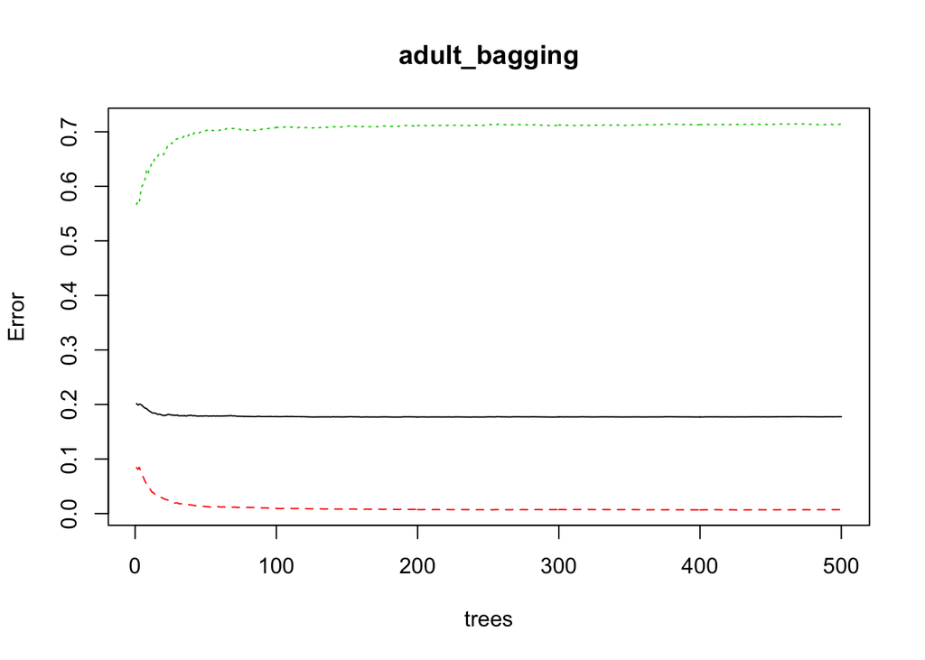

```r
adult_bagging <- randomForest(V15~.,data=adult, subset=adult.len, mtry=14, importance=TRUE)
plot(adult_bagging)
```

```r
adult_predict <- predict(adult_bagging, test)
adult_predict_confusion <- confusionMatrix(adult_predict, test$V15)
adult_predict_confusion$table
```

```
##           Reference
## Prediction  <=50K  >50K
##      <=50K   6154  1388
##      >50K      34   565
```

```r
accuracy <- adult_predict_confusion$overall[1]
accuracy
```

```
##  Accuracy
## 0.8253286
```

```r
# importance of predictors
adult_bagging$importance
```

```
##             <=50K          >50K MeanDecreaseAccuracy MeanDecreaseGini
## V1   6.482047e-03  1.489786e-02         8.511282e-03       1090.16939
## V2   2.905796e-03  3.251466e-03         2.987961e-03        297.17587
## V3  -1.364157e-04 -4.560100e-04        -2.129102e-04       1648.88157
## V4   1.304348e-02 -7.119378e-03         8.181493e-03        132.33000
## V5   1.820180e-02 -5.279553e-03         1.253129e-02       1010.28820
## V6   3.304829e-02 -3.675727e-03         2.419302e-02         64.81717
## V7   9.965383e-03  2.296325e-02         1.309979e-02        626.14639
## V8   3.952023e-02  5.453213e-03         3.130913e-02       1860.47967
## V9   3.991625e-04  1.298701e-04         3.350196e-04         88.52243
## V10  3.915318e-03 -1.457463e-03         2.618992e-03         51.97660
## V11  3.589721e-02  1.105106e-01         5.389205e-02        923.25002
## V12  5.063527e-03  4.225179e-02         1.403513e-02        300.53219
## V13  4.044093e-03  7.729947e-03         4.933131e-03        625.13831
## V14 -7.298244e-05  4.637758e-05        -4.414939e-05        215.00248
```

```r
# ipred package
adult_bagging <- ipredbagg(train$V15, X=train[,-15], nbagg=25,
                           control=rpart.control(minsplit=2, cp=0, xval=0),
                           comb=NULL, coob=FALSE, ns=length(train$V15), keepX = TRUE)
adult_predict <- predict(adult_bagging, test)
adult_predict_confusion <- confusionMatrix(adult_predict, test$V15)
adult_predict_confusion$table
```

```
##           Reference
## Prediction  <=50K  >50K
##      <=50K   5720   694
##      >50K     468  1259
```

```r
accuracy <- adult_predict_confusion$overall[1]
accuracy
```

```
##  Accuracy
## 0.8572657
```

# Resources

- [Improve Predictive Performance in R with Bagging via @rbloggers](http://www.r-bloggers.com/improve-predictive-performance-in-r-with-bagging/)
- [bagging {adabag} | inside-R | A Community Site for R](http://www.inside-r.org/packages/cran/adabag/docs/bagging)
- [bagging {ipred} | inside-R | A Community Site for R](http://www.inside-r.org/packages/cran/ipred/docs/bagging)
- [Bagging / Bootstrap Aggregation with R](http://amunategui.github.io/bagging-in-R/)